# IODS course project

### Q4. Numerical and graphical exploration

```r
# Preparing variables for analysis
alc$activities <- as.numeric(alc$activities)
alc$Pstatus <- as.numeric(alc$Pstatus)

# Installing relevant packages
library(dplyr)
library(ggplot2)
```

Correlation coefficients, distributional plots and cross tabulations:

```r
# Simple correlation coefficients
cor(alc$high_use, alc$Medu)
```

```
## [1] 0.01098796
```

```r
cor(alc$high_use, alc$studytime)
```

```
## [1] -0.2063247
```

```r
cor(alc$high_use, alc$activities)
```

```
## [1] -0.05710969
```

```r
cor(alc$high_use, alc$Pstatus)
```

```
## [1] -0.01260984
```

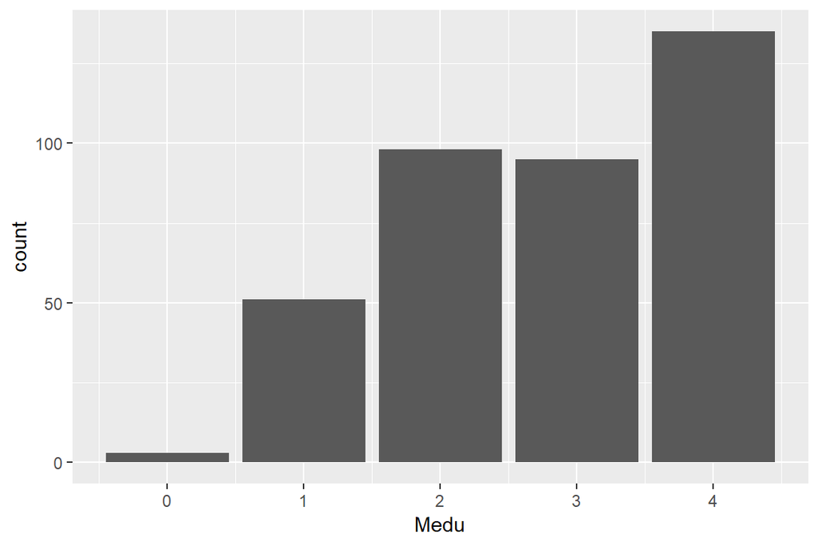

```r
# Distributional plots
g1 <- ggplot(alc, aes(x = Medu))
g2 <- ggplot(alc, aes(x = studytime))
g3 <- ggplot(alc, aes(x = activities))
g4 <- ggplot(alc, aes(x = Pstatus))

g1 + geom_bar()
```

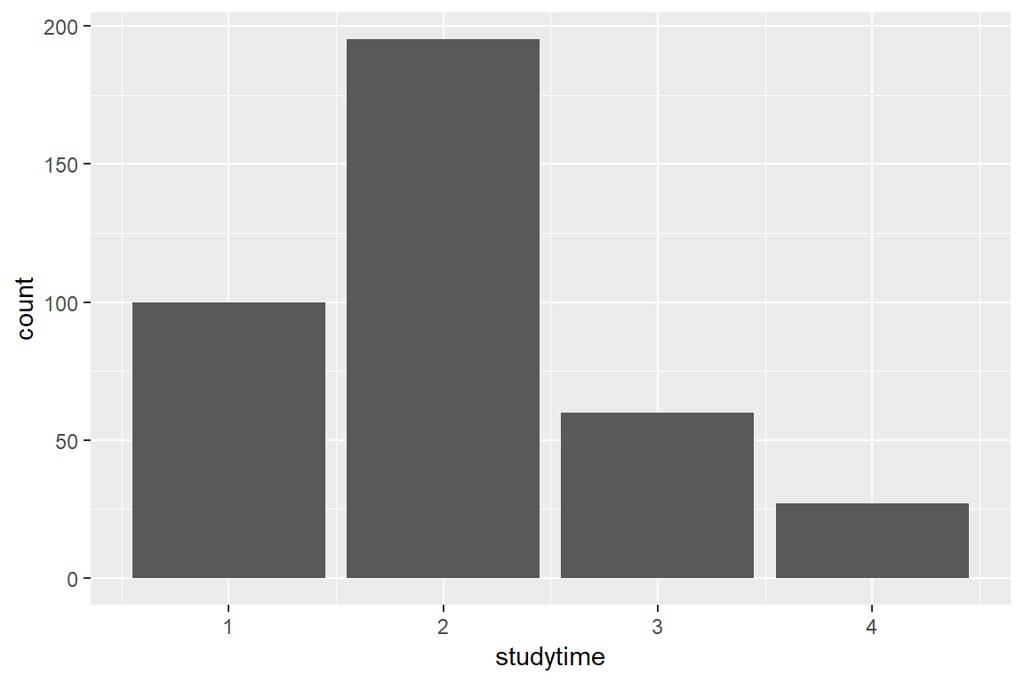

```r
g2 + geom_bar()
```

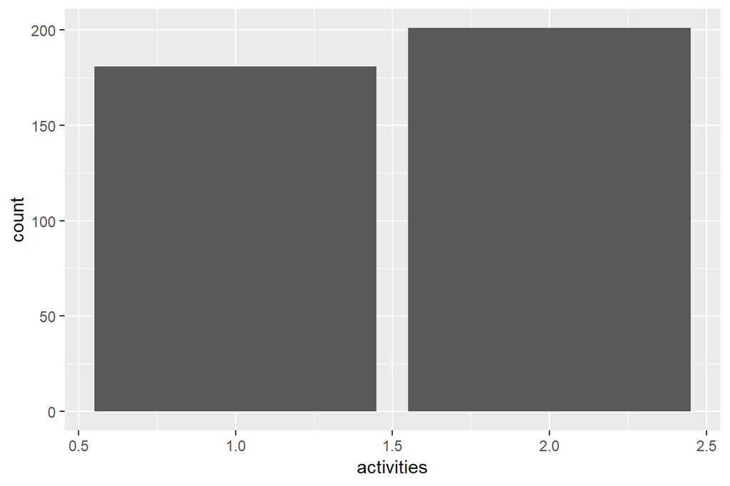

```r
g3 + geom_bar()
```

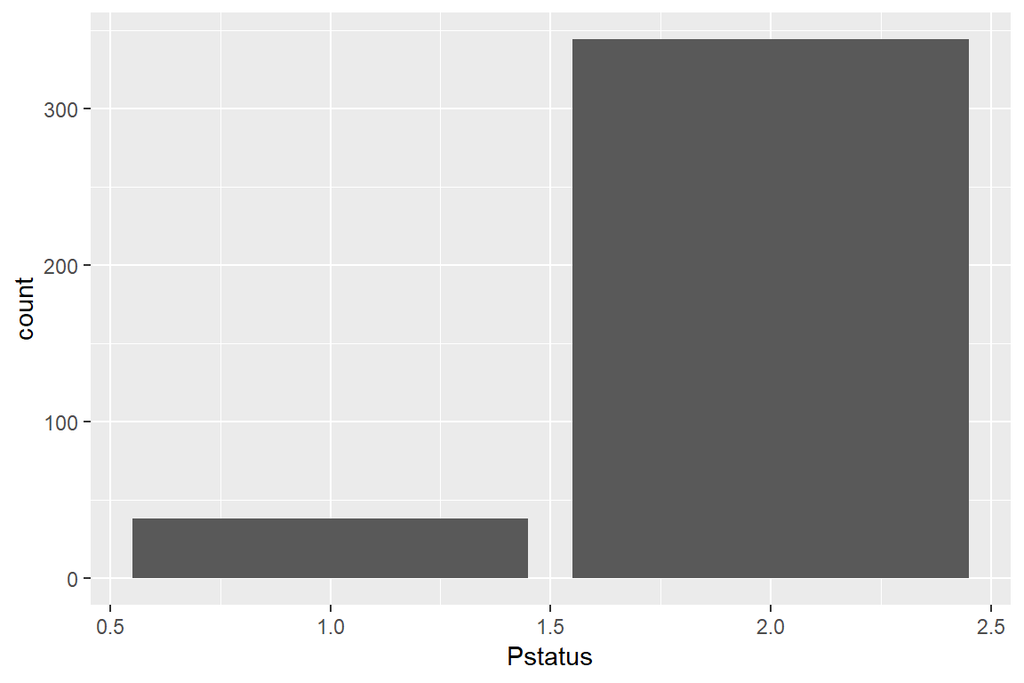

```r
g4 + geom_bar()
```

```r
# Cross tabulations
table(alc$high_use, alc$Medu)
```

```
##
##          0  1  2  3  4
##   FALSE  1 33 80 59 95
##   TRUE   2 18 18 36 40
```

```r
table(alc$high_use, alc$studytime)
```

```
##
##           1   2   3   4
##   FALSE  58 135  52  23
##   TRUE   42  60   8   4
```

```r
table(alc$high_use, alc$activities)
```

```
##
##           1   2
##   FALSE 122 146
##   TRUE   59  55
```

```r
table(alc$high_use, alc$Pstatus)
```

```
##
##           1   2
##   FALSE  26 242
##   TRUE   12 102
```

Moving on to connections between variables, the accuracy of my hypotheses is at best mixed. The most precise prediction is the one on study time, which is negatively correlated with high levels of alcohol consumption. All the other correlations are very close to zero, and the sign on mother’s education is actually *positive*.

### Q5. Logistic regression

```r
m1 <- glm(high_use ~ Medu + studytime + activities + Pstatus, data = alc, family = binomial)
summary(m1)
```

```
##
## Call:
## glm(formula = high_use ~ Medu + studytime + activities + Pstatus,
##     family = binomial, data = alc)
##
## Deviance Residuals:
##     Min       1Q   Median       3Q      Max
## -1.1253  -0.8471  -0.7652   1.2821   2.1530
##
## Coefficients:
##              Estimate Std. Error z value Pr(>|z|)
## (Intercept)  0.403199   0.884197   0.456 0.648386
## Medu         0.059429   0.107267   0.554 0.579564
## studytime   -0.597435   0.153868  -3.883 0.000103 ***
## activities  -0.178867   0.232579  -0.769 0.441860
## Pstatus      0.005724   0.380914   0.015 0.988011
## ---
## Signif. codes:  0 '***' 0.001 '**' 0.01 '*' 0.05 '.' 0.1 ' ' 1
##
## (Dispersion parameter for binomial family taken to be 1)
##
##     Null deviance: 465.68  on 381  degrees of freedom
## Residual deviance: 447.49  on 377  degrees of freedom
## AIC: 457.49
##
## Number of Fisher Scoring iterations: 4
```

```r
exp(coef(m1))
```

```
## (Intercept)        Medu   studytime  activities     Pstatus
##   1.4966050   1.0612299   0.5502210   0.8362175   1.0057402
```

```r
exp(confint(m1))
```

```
##                 2.5 %    97.5 %
## (Intercept) 0.2544469 8.3124648
## Medu        0.8608816 1.3120240
## studytime   0.4030077 0.7375984
## activities  0.5295809 1.3198457
## Pstatus     0.4856696 2.1873461
```

To ease interpretation, I exponentiated the coefficients from the logistic regression, and computed their respective confidence intervals. Now, the numbers represent odds ratios. As expected, for the three variables excluding study time the estimated confidence interval contains one. This implies, that we cannot tell whether an increase in each variable increases or decreases the odds of high alcohol consumption. Considering study time, however, the confidence interval is roughly 0.40-0.74, our best guess (i.e., the odds ratio) being 0.55. The interpretation is, that increasing study time for example from 2 to 5 hours to 5 to 10 hours squeezes the odds of high alcohol consumption by about 50%. An exact interpretation is awkward, since the study time categories are not of equal size.

### Q6. Evaluating predictive power

```r
m2 <- glm(high_use ~ studytime, data = alc, family = binomial)
summary(m2)
```

```
##
## Call:
## glm(formula = high_use ~ studytime, family = binomial, data = alc)
##
## Deviance Residuals:
##     Min       1Q   Median       3Q      Max
## -1.0603  -0.8314  -0.8314   1.2993   2.1010
##
## Coefficients:
##             Estimate Std. Error z value Pr(>|z|)
## (Intercept)   0.3209     0.3076   1.043    0.297
## studytime    -0.6029     0.1530  -3.941  8.1e-05 ***
## ---
## Signif. codes:  0 '***' 0.001 '**' 0.01 '*' 0.05 '.' 0.1 ' ' 1
##
## (Dispersion parameter for binomial family taken to be 1)
##
##     Null deviance: 465.68  on 381  degrees of freedom
## Residual deviance: 448.31  on 380  degrees of freedom
## AIC: 452.31
##
## Number of Fisher Scoring iterations: 4
```

```r
probabilities <- predict(m2, type = "response")
alc <- mutate(alc, probability = probabilities)
alc <- mutate(alc, prediction = probability > 0.5)
table(high_use = alc$high_use, prediction = alc$prediction) %>%
  prop.table() %>%
  addmargins()
```

```
##         prediction
## high_use     FALSE       Sum
##    FALSE 0.7015707 0.7015707
##    TRUE  0.2984293 0.2984293
##    Sum   1.0000000 1.0000000
```

```r
loss_func <- function(class, prob) {
  n_wrong <- abs(class - prob) > 0.5
  mean(n_wrong)
}
loss_func(class = alc$high_use, prob = 0)
```

```
## [1] 0.2984293
```

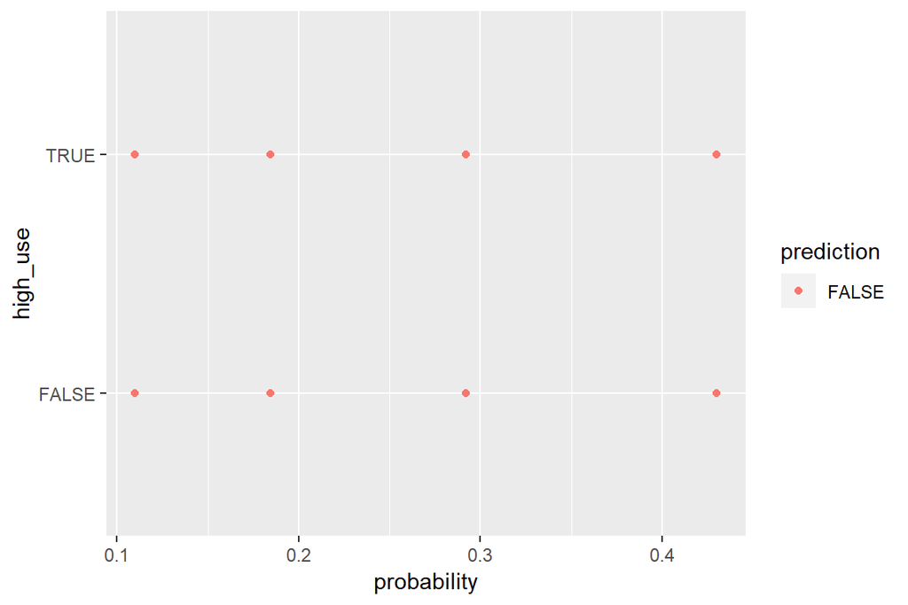

```r
alc %>%
  ggplot(aes(x = probability, y = high_use, col = prediction)) +
  geom_point()
```

Finally, I evaluate the predictive power of my logistic regression. Firstly, I do this by cross-tabulating the students who actually consume high level of alcohol, and the ones my model predicts to do so. Turns out, that after excluding the statistically insignificant variables, the bivariate model with only study times as an explanatory variable predicts that none of the students is a big drinker. Thus, the confusion matrix comes out as 2x1 matrix. Regardless, it can be concluded that the proportion of inaccurately classified individuals is roughly 30%. This result is further replicated by exploiting a loss function and drawing a rather trivial plot.

In terms of predictive power, the bivariate model is worthless compared to simply guessing that none of the students is a grand alcohol consumer: both approaches produce an identical prediction error.

# R Studio Exercise 4

### Q2. Reading and exploring the data

```r
library(MASS)
library(dplyr)
library(ggplot2)
library(corrplot)
library(reshape2)
library(magrittr)
data("Boston")
str(Boston)
```

```
## 'data.frame':    506 obs. of  14 variables:
##  $ crim   : num  0.00632 0.02731 0.02729 0.03237 0.06905 ...
##  $ zn     : num  18 0 0 0 0 0 12.5 12.5 12.5 12.5 ...
##  $ indus  : num  2.31 7.07 7.07 2.18 2.18 2.18 7.87 7.87 7.87 7.87 ...
##  $ chas   : int  0 0 0 0 0 0 0 0 0 0 ...
##  $ nox    : num  0.538 0.469 0.469 0.458 0.458 0.458 0.524 0.524 0.524 0.524 ...
##  $ rm     : num  6.58 6.42 7.18 7 7.15 ...
##  $ age    : num  65.2 78.9 61.1 45.8 54.2 58.7 66.6 96.1 100 85.9 ...
##  $ dis    : num  4.09 4.97 4.97 6.06 6.06 ...
##  $ rad    : int  1 2 2 3 3 3 5 5 5 5 ...
##  $ tax    : num  296 242 242 222 222 222 311 311 311 311 ...
##  $ ptratio: num  15.3 17.8 17.8 18.7 18.7 18.7 15.2 15.2 15.2 15.2 ...
##  $ black  : num  397 397 393 395 397 ...
##  $ lstat  : num  4.98 9.14 4.03 2.94 5.33 ...
##  $ medv   : num  24 21.6 34.7 33.4 36.2 28.7 22.9 27.1 16.5 18.9 ...
```

```r
dim(Boston)
```

```
## [1] 506  14
```

The dataset for week 4 is a default dataset included in the R package MASS. The dataset describes housing values and various social parameters in different suburbs of Boston. It consists of 506 observations of 14 variables.

### Q3. Summary statistics and graphical overview

**Summary statistics**

```r
summary(Boston)
```

```
##       crim                zn             indus            chas
##  Min.   : 0.00632   Min.   :  0.00   Min.   : 0.46   Min.   :0.00000
##  1st Qu.: 0.08204   1st Qu.:  0.00   1st Qu.: 5.19   1st Qu.:0.00000
##  Median : 0.25651   Median :  0.00   Median : 9.69   Median :0.00000
##  Mean   : 3.61352   Mean   : 11.36   Mean   :11.14   Mean   :0.06917
##  3rd Qu.: 3.67708   3rd Qu.: 12.50   3rd Qu.:18.10   3rd Qu.:0.00000
##  Max.   :88.97620   Max.   :100.00   Max.   :27.74   Max.   :1.00000
##       nox               rm             age              dis
##  Min.   :0.3850   Min.   :3.561   Min.   :  2.90   Min.   : 1.130
##  1st Qu.:0.4490   1st Qu.:5.886   1st Qu.: 45.02   1st Qu.: 2.100
##  Median :0.5380   Median :6.208   Median : 77.50   Median : 3.207
##  Mean   :0.5547   Mean   :6.285   Mean   : 68.57   Mean   : 3.795
##  3rd Qu.:0.6240   3rd Qu.:6.623   3rd Qu.: 94.08   3rd Qu.: 5.188
##  Max.   :0.8710   Max.   :8.780   Max.   :100.00   Max.   :12.127
##       rad              tax           ptratio          black
##  Min.   : 1.000   Min.   :187.0   Min.   :12.60   Min.   :  0.32
##  1st Qu.: 4.000   1st Qu.:279.0   1st Qu.:17.40   1st Qu.:375.38
##  Median : 5.000   Median :330.0   Median :19.05   Median :391.44
##  Mean   : 9.549   Mean   :408.2   Mean   :18.46   Mean   :356.67
##  3rd Qu.:24.000   3rd Qu.:666.0   3rd Qu.:20.20   3rd Qu.:396.23
##  Max.   :24.000   Max.   :711.0   Max.   :22.00   Max.   :396.90
##      lstat            medv
##  Min.   : 1.73   Min.   : 5.00
##  1st Qu.: 6.95   1st Qu.:17.02
##  Median :11.36   Median :21.20
##  Mean   :12.65   Mean   :22.53
##  3rd Qu.:16.95   3rd Qu.:25.00
##  Max.   :37.97   Max.   :50.00
```

**Graphical overview**

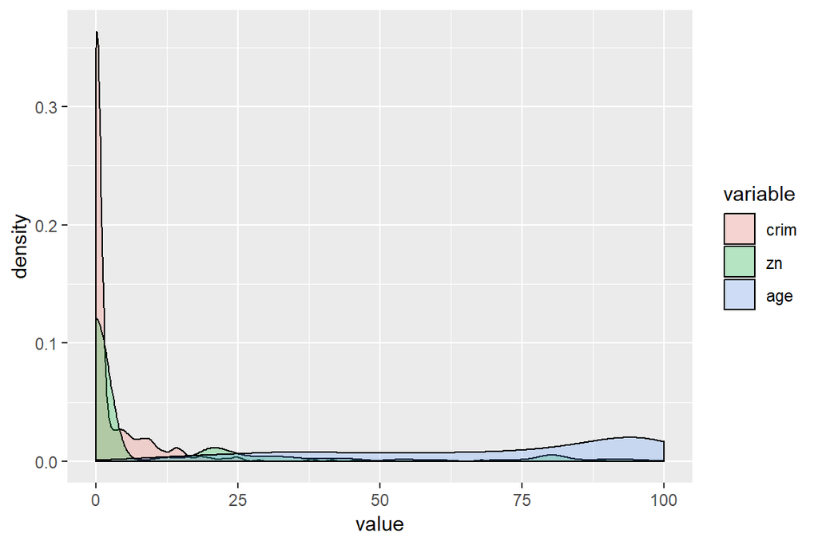

```r
widedata1 <- Boston %>%
  dplyr::select(crim, zn, age) %>%
  melt()
ggplot(widedata1, aes(x = value, fill = variable)) + geom_density(alpha = 0.25)
```

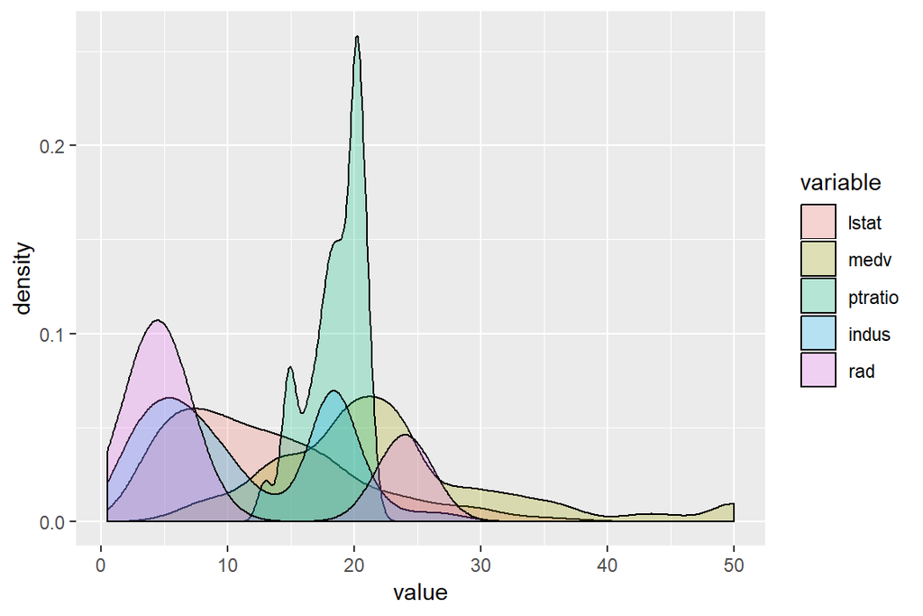

```r
widedata2 <- Boston %>%
  dplyr::select(lstat, medv, ptratio, indus, rad) %>%
  melt()
ggplot(widedata2, aes(x = value, fill = variable)) + geom_density(alpha = 0.25)
```

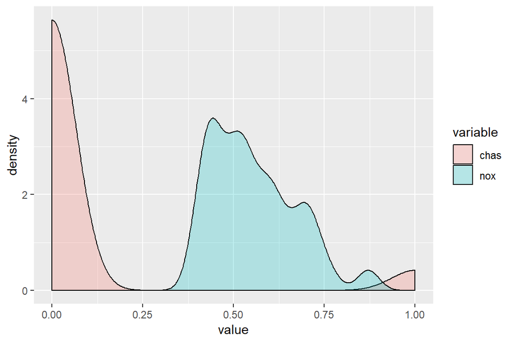

```r
widedata3 <- Boston %>%
  dplyr::select(chas, nox) %>%
  melt()
  ggplot(widedata3, aes(x = value, fill = variable)) + geom_density(alpha = 0.25)
```

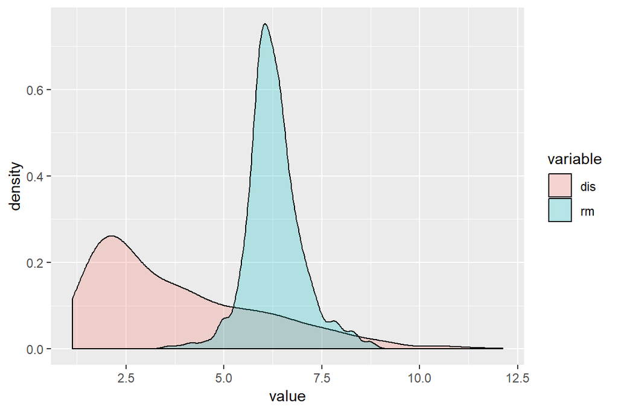

```r
widedata4 <- Boston %>%
  dplyr::select(dis, rm) %>%
  melt()
  ggplot(widedata4, aes(x = value, fill = variable)) + geom_density(alpha = 0.25)
```

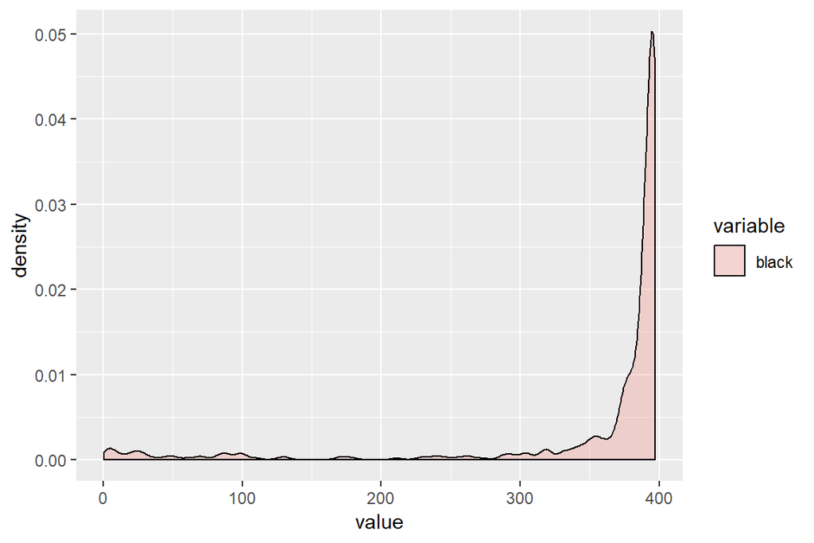

```r
widedata5 <- Boston %>%
  dplyr::select(black) %>%
  melt()
  ggplot(widedata5, aes(x = value, fill = variable)) + geom_density(alpha = 0.25)
```

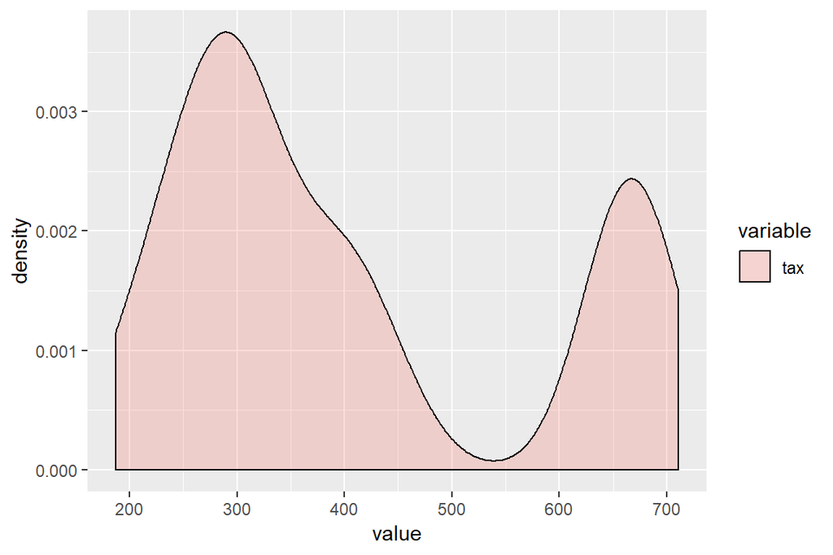

```r
widedata6 <- Boston %>%
  dplyr::select(tax) %>%
  melt()
  ggplot(widedata6, aes(x = value, fill = variable)) + geom_density(alpha = 0.25)
```

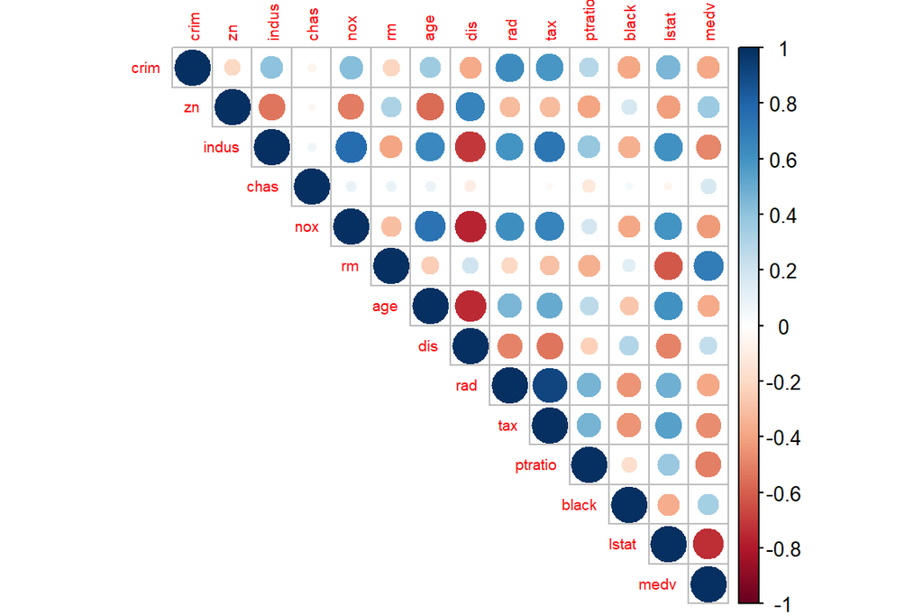

```r
cor_matrix <- cor(Boston)
corrplot(cor_matrix, method="circle", type = "upper", tl.cex = 0.6)
```

Considering the relationships between variables, few variables stand out when focusing on the target variable, i.e. per capita crime rate. Turns out, that quite surprisingly, property tax rate and accessibility to radial highways show the strongest positive correlation with the crime rate in a bivariate setting. Housing value, proportion of blacks and distance to employment centres experience the strongest negative correlation.

### Q4. Getting data ready for analysis

**Standardizing, wrangling and splitting the data**

```r
# Scaling the data, and creating a new categorical variable crime
boston_scaled <- scale(Boston)
boston_scaled <- as.data.frame(boston_scaled)
summary(boston_scaled)
```

```
##       crim                 zn               indus
##  Min.   :-0.419367   Min.   :-0.48724   Min.   :-1.5563
##  1st Qu.:-0.410563   1st Qu.:-0.48724   1st Qu.:-0.8668
##  Median :-0.390280   Median :-0.48724   Median :-0.2109
##  Mean   : 0.000000   Mean   : 0.00000   Mean   : 0.0000
##  3rd Qu.: 0.007389   3rd Qu.: 0.04872   3rd Qu.: 1.0150
##  Max.   : 9.924110   Max.   : 3.80047   Max.   : 2.4202
##       chas              nox                rm               age
##  Min.   :-0.2723   Min.   :-1.4644   Min.   :-3.8764   Min.   :-2.3331
##  1st Qu.:-0.2723   1st Qu.:-0.9121   1st Qu.:-0.5681   1st Qu.:-0.8366
##  Median :-0.2723   Median :-0.1441   Median :-0.1084   Median : 0.3171
##  Mean   : 0.0000   Mean   : 0.0000   Mean   : 0.0000   Mean   : 0.0000
##  3rd Qu.:-0.2723   3rd Qu.: 0.5981   3rd Qu.: 0.4823   3rd Qu.: 0.9059
##  Max.   : 3.6648   Max.   : 2.7296   Max.   : 3.5515   Max.   : 1.1164
##       dis               rad               tax             ptratio
##  Min.   :-1.2658   Min.   :-0.9819   Min.   :-1.3127   Min.   :-2.7047
##  1st Qu.:-0.8049   1st Qu.:-0.6373   1st Qu.:-0.7668   1st Qu.:-0.4876
##  Median :-0.2790   Median :-0.5225   Median :-0.4642   Median : 0.2746
##  Mean   : 0.0000   Mean   : 0.0000   Mean   : 0.0000   Mean   : 0.0000
##  3rd Qu.: 0.6617   3rd Qu.: 1.6596   3rd Qu.: 1.5294   3rd Qu.: 0.8058
##  Max.   : 3.9566   Max.   : 1.6596   Max.   : 1.7964   Max.   : 1.6372
##      black             lstat              medv
##  Min.   :-3.9033   Min.   :-1.5296   Min.   :-1.9063
##  1st Qu.: 0.2049   1st Qu.:-0.7986   1st Qu.:-0.5989
##  Median : 0.3808   Median :-0.1811   Median :-0.1449
##  Mean   : 0.0000   Mean   : 0.0000   Mean   : 0.0000
##  3rd Qu.: 0.4332   3rd Qu.: 0.6024   3rd Qu.: 0.2683
##  Max.   : 0.4406   Max.   : 3.5453   Max.   : 2.9865
```

```r
bins <- quantile(boston_scaled$crim)
crime <- cut(boston_scaled$crim, breaks = bins, include.lowest = T, label = c("low", "med-low", "med-high", "high"))
boston_scaled <- dplyr::select(boston_scaled, -crim)
boston_scaled <- data.frame(boston_scaled, crime)

# Splitting the data into a train and test sets
set.seed(123)
n <- nrow(boston_scaled)
ind <- sample(n, size = n * 0.8)
train <- boston_scaled[ind,]
test <- boston_scaled[-ind,]
```

Standardization of the data centers each variable to zero. The variables are also scaled with their respective standard deviation. In practice, this transformation moulds the variables in a way which makes their distribution closer to the standard normal distribution. After standardization, I added a new variable to the dataset, *crime*, which is a categorical version of the continuous variable *crim*. *Crime* was split into four equal-sized levels by first identifying its quantiles. Moreover, the old *crim* variable was deleted. As a last preparation before the analysis, I divided the data into train and test sets, where a random sample including 80% of the data was assigned to the train set, and the rest to the other set.

### Q5. Linear discriminant analysis

```r
ldam <- lda(crime ~ ., data = train)
ldam
```

```
## Call:
## lda(crime ~ ., data = train)
##
## Prior probabilities of groups:
##       low   med-low  med-high      high
## 0.2500000 0.2475248 0.2549505 0.2475248
##
## Group means:
##                  zn      indus        chas        nox          rm
## low       0.9432005 -0.8959713 -0.11640431 -0.8577158  0.44620905
## med-low  -0.1512978 -0.3010310 -0.07547406 -0.5591764 -0.11907536
## med-high -0.4023185  0.2609362  0.18636222  0.4392319  0.04779161
## high     -0.4872402  1.0149946 -0.07547406  1.0412268 -0.50541663
##                 age        dis        rad        tax     ptratio
## low      -0.8546026  0.8232513 -0.6953230 -0.7314517 -0.45097009
## med-low  -0.3467956  0.2952511 -0.5420083 -0.4653999 -0.03350366
## med-high  0.4318874 -0.4060664 -0.4087527 -0.2821208 -0.32611400
## high      0.7952399 -0.8387924  1.6596029  1.5294129  0.80577843
##                black       lstat        medv
## low       0.37835870 -0.76633833  0.51252310
## med-low   0.32163001 -0.18506538  0.01078532
## med-high  0.08166164  0.03210543  0.15583308
## high     -0.74993410  0.87136020 -0.65964311
##
## Coefficients of linear discriminants:
##                 LD1         LD2         LD3
## zn       0.08288224  0.74545012 -1.02758413
## indus    0.03371880 -0.27414286  0.12800485
## chas    -0.07688231 -0.04569133  0.03313223
## nox      0.24620783 -0.70692830 -1.31233352
## rm      -0.13308714 -0.06060304 -0.15792484
## age      0.29339946 -0.28245910 -0.17691125
## dis     -0.04642187 -0.28428720  0.07074842
## rad      3.40029809  0.91155778 -0.10269503
## tax      0.04070331 -0.03257583  0.61283757
## ptratio  0.11422801  0.09094945 -0.21802056
## black   -0.15410658  0.03229362  0.15457698
## lstat    0.19460392 -0.28843142  0.29476658
## medv     0.17982251 -0.40689877 -0.20349106
##
## Proportion of trace:
##    LD1    LD2    LD3
## 0.9510 0.0368 0.0122
```

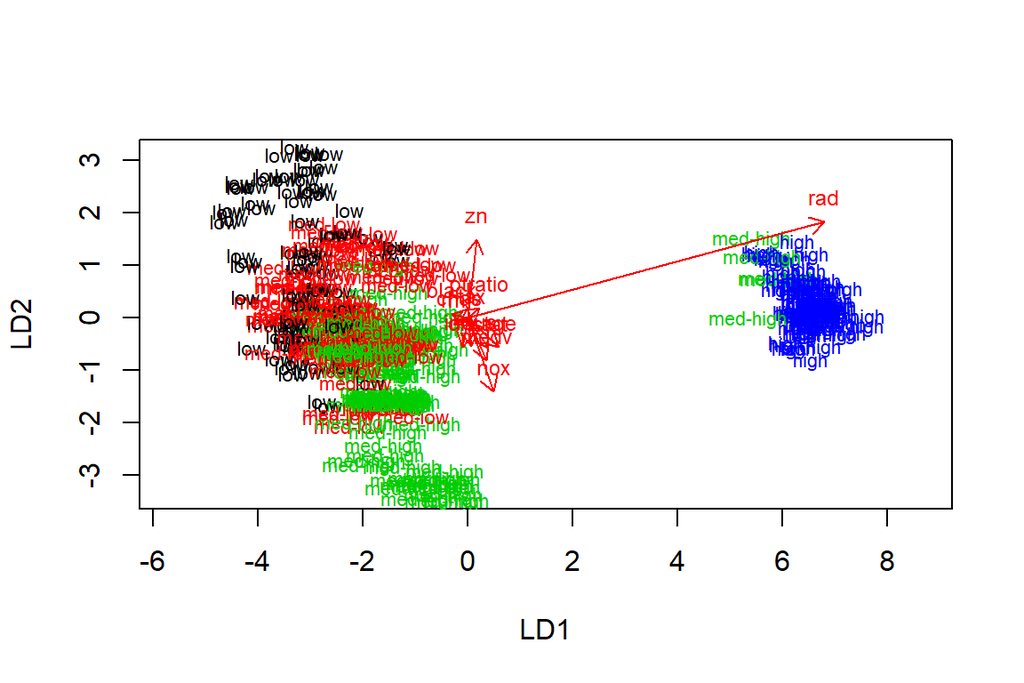

```r
classes <- as.numeric(train$crime)

lda.arrows <- function(x, myscale = 1, arrow_heads = 0.1, color = "red", tex = 0.75, choices = c(1,2)){
  heads <- coef(x)
  arrows(x0 = 0, y0 = 0,
         x1 = myscale * heads[,choices[1]],
         y1 = myscale * heads[,choices[2]], col=color, length = arrow_heads)
  text(myscale * heads[,choices], labels = row.names(heads),
       cex = tex, col=color, pos=3)
}

plot(ldam, dimen = 2, col = classes, pch = classes)
lda.arrows(ldam, myscale = 2)
```

Next, I fitted a linear discriminant analysis with the train set, while using the categorical crime rate as a target variable. To briefly comment the results, one distinct pattern could be pointed out. It appears, that if the train set is classified into two categories, the accessibility to radial highways is the variable which discriminates per capita crime rates the best.

### Q6. Testing the model’s predictive power

```r
#
correct_classes <- test$crime
test <- dplyr::select(test, -crime)

ldapred <- predict(ldam, newdata = test)
table(correct = correct_classes, predicted = ldapred$class)
```

```
##           predicted
## correct    low med-low med-high high
##   low       16      10        0    0
##   med-low    7      15        4    0
##   med-high   1       6       15    1
##   high       0       0        1   26
```

### Q7. K-means

```r
# Reloading the data and computing Euclidian distances
data("Boston")
boston_scaled_km <- scale(Boston)
dist_eu <- dist(boston_scaled_km)
str(dist_eu)
```

```
##  'dist' num [1:127765] 1.94 2.28 2.57 2.69 2.24 ...
##  - attr(*, "Size")= int 506
##  - attr(*, "Labels")= chr [1:506] "1" "2" "3" "4" ...
##  - attr(*, "Diag")= logi FALSE
##  - attr(*, "Upper")= logi FALSE
##  - attr(*, "method")= chr "euclidean"
##  - attr(*, "call")= language dist(x = boston_scaled_km)
```

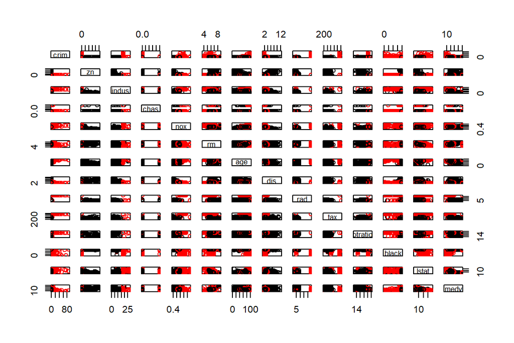

```r
# K-means clustering with two clusters
set.seed(123)
km <- kmeans(boston_scaled_km, centers = 2)
pairs(Boston, col = km$cluster)
```

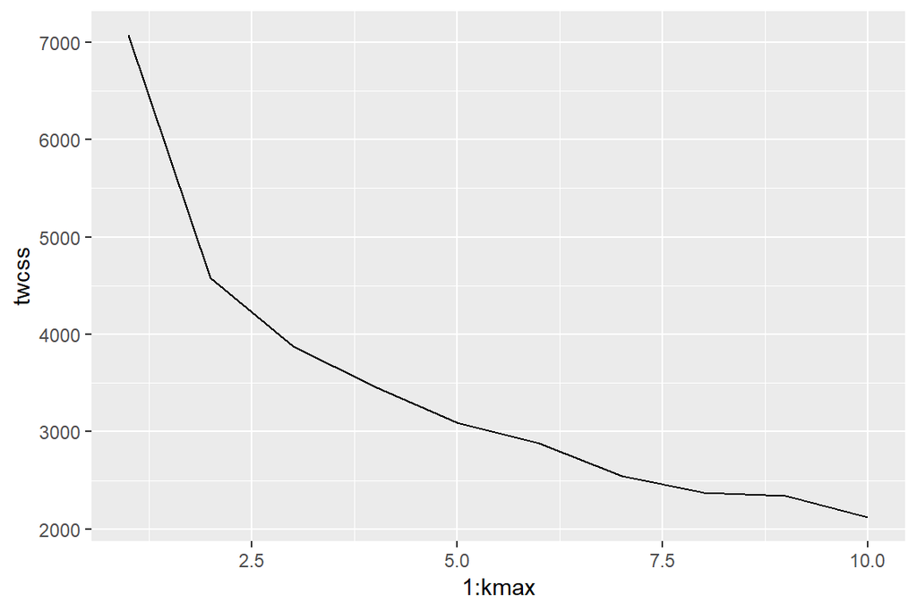

```r
# Finding the optimal number of clusters, and visualizing the results
kmax <- 10
twcss <- sapply(1:kmax, function(k){kmeans(boston_scaled_km, k)$tot.withinss})
qplot(x = 1:kmax, y = twcss, geom = 'line')
```

Done with the classification, I experimented a bit with clustering. Starting from a scratch, I reloaded the Boston dataset. Next, I looked a bit under the hood of k-means clustering algorithm, and created a distance matrix, which computes observations’ pairwise Euclidian distances. Moving on to analysis, I ran the k-means algorithm on the data with two centroids, and visualized the clusters with respect to each variable. To minimize arbitrariness when selecting the number of centroids, I computed total within cluster sum of squares to determine the optimal number of centroids, i.e. clusters. Plotting the sums with varying number of clusters from one to ten, I concluded that two clusters is indeed the optimal choice: the optimum is represented as the most distinct drop in the sum.

# R Studio Exercise 5

### Q1. Reading and exploring the data

**Graphical overview**

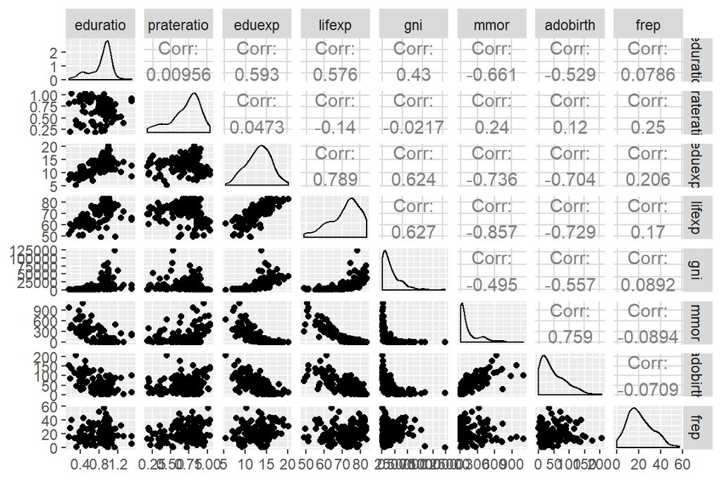

```r
library(GGally)

human <- read.csv("C:/Users/Teppo/Documents/GitHub/IODS-project/data/human2.csv", row.names = 1)
ggpairs(human)
```

**Summary statistics**

```r
dim(human)
```

```
## [1] 155   8
```

```r
summary(human)
```

```
##     eduratio        prateratio         eduexp          lifexp
##  Min.   :0.1717   Min.   :0.1857   Min.   : 5.40   Min.   :49.00
##  1st Qu.:0.7264   1st Qu.:0.5984   1st Qu.:11.25   1st Qu.:66.30
##  Median :0.9375   Median :0.7535   Median :13.50   Median :74.20
##  Mean   :0.8529   Mean   :0.7074   Mean   :13.18   Mean   :71.65
##  3rd Qu.:0.9968   3rd Qu.:0.8535   3rd Qu.:15.20   3rd Qu.:77.25
##  Max.   :1.4967   Max.   :1.0380   Max.   :20.20   Max.   :83.50
##       gni              mmor           adobirth           frep
##  Min.   :   581   Min.   :   1.0   Min.   :  0.60   Min.   : 0.00
##  1st Qu.:  4198   1st Qu.:  11.5   1st Qu.: 12.65   1st Qu.:12.40
##  Median : 12040   Median :  49.0   Median : 33.60   Median :19.30
##  Mean   : 17628   Mean   : 149.1   Mean   : 47.16   Mean   :20.91
##  3rd Qu.: 24512   3rd Qu.: 190.0   3rd Qu.: 71.95   3rd Qu.:27.95
##  Max.   :123124   Max.   :1100.0   Max.   :204.80   Max.   :57.50
```

Moving on to relations between variables, we are able to distinguish couple of strong correlations. Firstly, expected years of education and life expectancy share a distinct positive correlation, as well as maternal mortality ratio and adolescent birth rate. Furthermore, maternal mortality rate and adolescent birth rate are seemingly negatively correlated with expected years of education and life expectancy.

### Q2. First trial with principal component analysis

```r
pca_human <- prcomp(human)
summary(pca_human)
```

```
## Importance of components:
##                              PC1      PC2   PC3   PC4   PC5   PC6    PC7
## Standard deviation     1.854e+04 185.5219 25.19 11.45 3.766 1.566 0.1912
## Proportion of Variance 9.999e-01   0.0001  0.00  0.00 0.000 0.000 0.0000
## Cumulative Proportion  9.999e-01   1.0000  1.00  1.00 1.000 1.000 1.0000
##                           PC8
## Standard deviation     0.1591
## Proportion of Variance 0.0000
## Cumulative Proportion  1.0000
```

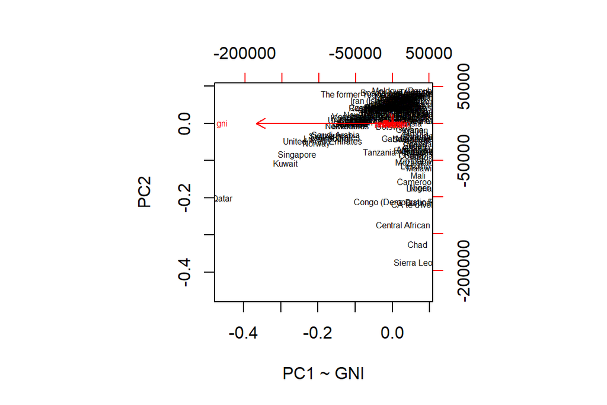

```r
biplot(pca_human, choices = 1:2, cex = c(0.5, 0.5), xlab = "PC1 ~ GNI", ylab = "PC2")
```

According to my first trial on principal component analysis (PCA), the first principal component, PC1, appears to capture slightly under 100% of the variability between observations. This is due to the unscaled data, which leads to a situation where the analysis is driven solely by the variable measuring gross national income (GNI). Since GNI’s range is greater than any other variable’s by far, it dilutes the computation.

### Q3 & Q4. PCA with scaled data

```r
str(human)
```

```
## 'data.frame':    155 obs. of  8 variables:
##  $ eduratio  : num  1.007 0.997 0.983 0.989 0.969 ...
##  $ prateratio: num  0.891 0.819 0.825 0.884 0.829 ...
##  $ eduexp    : num  17.5 20.2 15.8 18.7 17.9 16.5 18.6 16.5 15.9 19.2 ...
##  $ lifexp    : num  81.6 82.4 83 80.2 81.6 80.9 80.9 79.1 82 81.8 ...
##  $ gni       : int  64992 42261 56431 44025 45435 43919 39568 52947 42155 32689 ...
##  $ mmor      : int  4 6 6 5 6 7 9 28 11 8 ...
##  $ adobirth  : num  7.8 12.1 1.9 5.1 6.2 3.8 8.2 31 14.5 25.3 ...
##  $ frep      : num  39.6 30.5 28.5 38 36.9 36.9 19.9 19.4 28.2 31.4 ...
```

```r
human_scaled <- scale(human)
pca_human_scaled <- prcomp(human_scaled)
summary(pca_human_scaled)
```

```
## Importance of components:
##                           PC1    PC2     PC3     PC4     PC5     PC6
## Standard deviation     2.0708 1.1397 0.87505 0.77886 0.66196 0.53631
## Proportion of Variance 0.5361 0.1624 0.09571 0.07583 0.05477 0.03595
## Cumulative Proportion  0.5361 0.6984 0.79413 0.86996 0.92473 0.96069
##                            PC7     PC8
## Standard deviation     0.45900 0.32224
## Proportion of Variance 0.02634 0.01298
## Cumulative Proportion  0.98702 1.00000
```

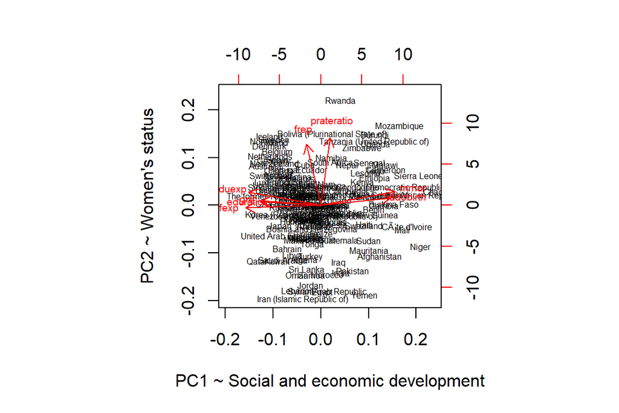

```r
biplot(pca_human_scaled, choices = 1:2, cex = c(0.5, 0.6), xlab = "PC1 ~ Social and economic development", ylab = "PC2 ~ Women's status")
```

```r
cor(human_scaled)
```

```
##                eduratio   prateratio      eduexp     lifexp         gni
## eduratio    1.000000000  0.009564039  0.59325156  0.5760299  0.43030485
## prateratio  0.009564039  1.000000000  0.04732183 -0.1400125 -0.02173971
## eduexp      0.593251562  0.047321827  1.00000000  0.7894392  0.62433940
## lifexp      0.576029853 -0.140012504  0.78943917  1.0000000  0.62666411
## gni         0.430304846 -0.021739705  0.62433940  0.6266641  1.00000000
## mmor       -0.660931770  0.240461075 -0.73570257 -0.8571684 -0.49516234
## adobirth   -0.529418415  0.120158862 -0.70356489 -0.7291774 -0.55656208
## frep        0.078635285  0.250232608  0.20608156  0.1700863  0.08920818
##                  mmor   adobirth        frep
## eduratio   -0.6609318 -0.5294184  0.07863528
## prateratio  0.2404611  0.1201589  0.25023261
## eduexp     -0.7357026 -0.7035649  0.20608156
## lifexp     -0.8571684 -0.7291774  0.17008631
## gni        -0.4951623 -0.5565621  0.08920818
## mmor        1.0000000  0.7586615 -0.08944000
## adobirth    0.7586615  1.0000000 -0.07087810
## frep       -0.0894400 -0.0708781  1.00000000
```

### Q5. Multiple correspondence analysis

**Introducing the ‘tea’ dataset**

```r
library(FactoMineR)
data("tea")
str(tea)
```

```
## 'data.frame':    300 obs. of  36 variables:
##  $ breakfast       : Factor w/ 2 levels "breakfast","Not.breakfast": 1 1 2 2 1 2 1 2 1 1 ...
##  $ tea.time        : Factor w/ 2 levels "Not.tea time",..: 1 1 2 1 1 1 2 2 2 1 ...
##  $ evening         : Factor w/ 2 levels "evening","Not.evening": 2 2 1 2 1 2 2 1 2 1 ...
##  $ lunch           : Factor w/ 2 levels "lunch","Not.lunch": 2 2 2 2 2 2 2 2 2 2 ...
##  $ dinner          : Factor w/ 2 levels "dinner","Not.dinner": 2 2 1 1 2 1 2 2 2 2 ...
##  $ always          : Factor w/ 2 levels "always","Not.always": 2 2 2 2 1 2 2 2 2 2 ...
##  $ home            : Factor w/ 2 levels "home","Not.home": 1 1 1 1 1 1 1 1 1 1 ...
##  $ work            : Factor w/ 2 levels "Not.work","work": 1 1 2 1 1 1 1 1 1 1 ...
##  $ tearoom         : Factor w/ 2 levels "Not.tearoom",..: 1 1 1 1 1 1 1 1 1 2 ...
##  $ friends         : Factor w/ 2 levels "friends","Not.friends": 2 2 1 2 2 2 1 2 2 2 ...
##  $ resto           : Factor w/ 2 levels "Not.resto","resto": 1 1 2 1 1 1 1 1 1 1 ...
##  $ pub             : Factor w/ 2 levels "Not.pub","pub": 1 1 1 1 1 1 1 1 1 1 ...
##  $ Tea             : Factor w/ 3 levels "black","Earl Grey",..: 1 1 2 2 2 2 2 1 2 1 ...
##  $ How             : Factor w/ 4 levels "alone","lemon",..: 1 3 1 1 1 1 1 3 3 1 ...
```

[output cut: 22 more lines]

```r
dim(tea)
```

```
## [1] 300  36
```

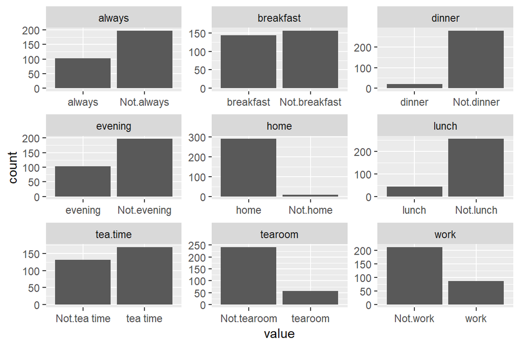

```r
library(dplyr)
library(tidyr)

gather(tea[,1:9]) %>%
  ggplot(aes(value)) +
  geom_bar() +
  facet_wrap("key", scales = "free")
```

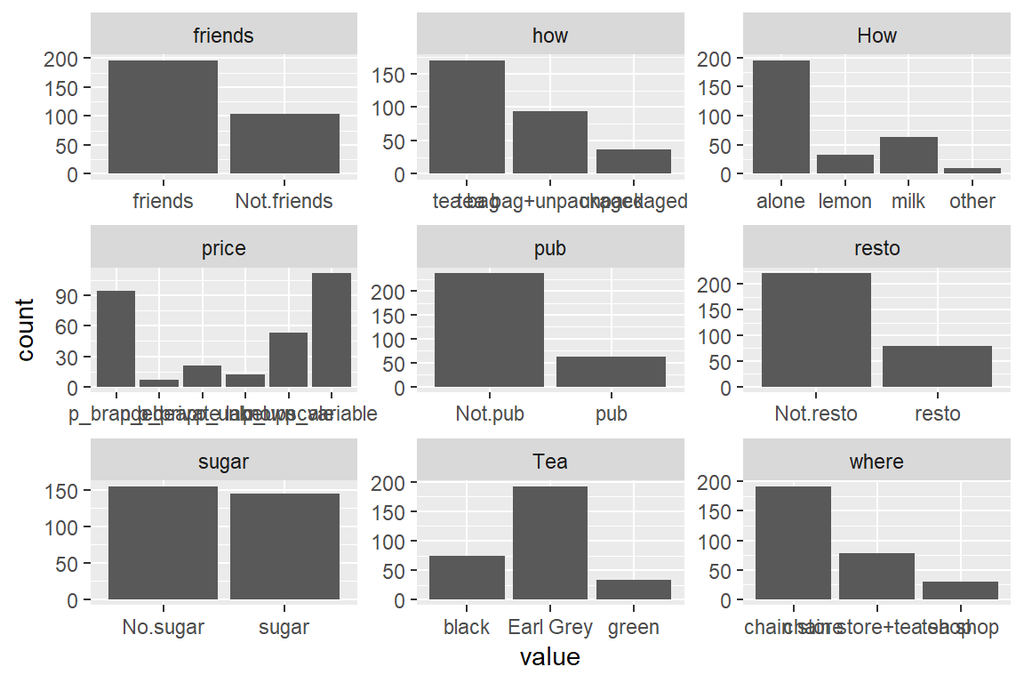

```r
gather(tea[,10:18]) %>%
  ggplot(aes(value)) +
  geom_bar() +
  facet_wrap("key", scales = "free")
```

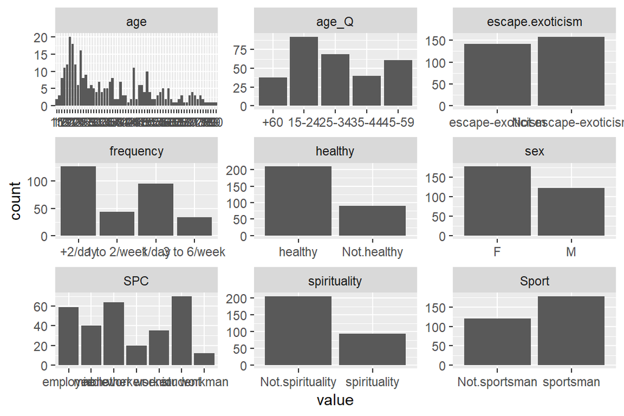

```r
gather(tea[,19:27]) %>%
  ggplot(aes(value)) +
  geom_bar() +
  facet_wrap("key", scales = "free")
```

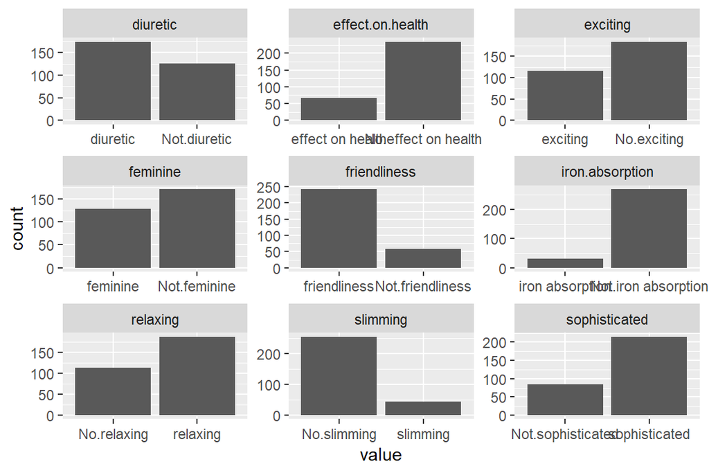

```r
gather(tea[,28:36]) %>%
  ggplot(aes(value)) +
  geom_bar() +
  facet_wrap("key", scales = "free")
```

As a final exercise, I performed a multiple correspondence analysis with a dataset regarding the habits and perceptions of English tea-drinkers, provided within the R package *FactoMineR*. As a first glance, we can observe that the dataset consists of 300 observations and 36 variables. A quick graphical exploration offers delightful insights to the tea-drinking convetions in England, like that based on this sample, tea is mostly drank at home, a preferred tea label is Earl Grey, and most respondents find tea-drinking neither exciting nor feminine, but sophisticated instead.

**MCA**

```r
keep_columns <- c("Tea", "How", "how", "sugar", "where", "lunch")
tea_time <- dplyr::select(tea, one_of(keep_columns))
mca <- MCA(tea_time, graph = F)
summary(mca)
```

```
##
## Call:
## MCA(X = tea_time, graph = F)
##
##
## Eigenvalues
##                        Dim.1   Dim.2   Dim.3   Dim.4   Dim.5   Dim.6
## Variance               0.279   0.261   0.219   0.189   0.177   0.156
## % of var.             15.238  14.232  11.964  10.333   9.667   8.519
## Cumulative % of var.  15.238  29.471  41.435  51.768  61.434  69.953
##                        Dim.7   Dim.8   Dim.9  Dim.10  Dim.11
## Variance               0.144   0.141   0.117   0.087   0.062
## % of var.              7.841   7.705   6.392   4.724   3.385
## Cumulative % of var.  77.794  85.500  91.891  96.615 100.000
##
## Individuals (the 10 first)
##                       Dim.1    ctr   cos2    Dim.2    ctr   cos2    Dim.3
## 1                  | -0.298  0.106  0.086 | -0.328  0.137  0.105 | -0.327
## 2                  | -0.237  0.067  0.036 | -0.136  0.024  0.012 | -0.695
## 3                  | -0.369  0.162  0.231 | -0.300  0.115  0.153 | -0.202
## 4                  | -0.530  0.335  0.460 | -0.318  0.129  0.166 |  0.211
## 5                  | -0.369  0.162  0.231 | -0.300  0.115  0.153 | -0.202
## 6                  | -0.369  0.162  0.231 | -0.300  0.115  0.153 | -0.202
## 7                  | -0.369  0.162  0.231 | -0.300  0.115  0.153 | -0.202
## 8                  | -0.237  0.067  0.036 | -0.136  0.024  0.012 | -0.695
## 9                  |  0.143  0.024  0.012 |  0.871  0.969  0.435 | -0.067
## 10                 |  0.476  0.271  0.140 |  0.687  0.604  0.291 | -0.650
##                       ctr   cos2
## 1                   0.163  0.104 |
## 2                   0.735  0.314 |
## 3                   0.062  0.069 |
## 4                   0.068  0.073 |
## 5                   0.062  0.069 |
## 6                   0.062  0.069 |
## 7                   0.062  0.069 |
## 8                   0.735  0.314 |
## 9                   0.007  0.003 |
## 10                  0.643  0.261 |
##
## Categories (the 10 first)
```

[output cut: 16 more lines]

```
## lemon                0.035   3.226 |   1.329  14.771   0.218   8.081 |
## milk                 0.020   2.422 |   0.013   0.003   0.000   0.116 |
## other                0.102   5.534 |  -2.524  14.526   0.197  -7.676 |
## tea bag              0.161  -6.941 |  -0.065   0.183   0.006  -1.287 |
## tea bag+unpackaged   0.478  11.956 |   0.019   0.009   0.000   0.226 |
## unpackaged           0.141  -6.482 |   0.257   0.602   0.009   1.640 |
##
## Categorical variables (eta2)
##                      Dim.1 Dim.2 Dim.3
## Tea                | 0.126 0.108 0.410 |
## How                | 0.076 0.190 0.394 |
## how                | 0.708 0.522 0.010 |
## sugar              | 0.065 0.001 0.336 |
## where              | 0.702 0.681 0.055 |
## lunch              | 0.000 0.064 0.111 |
```

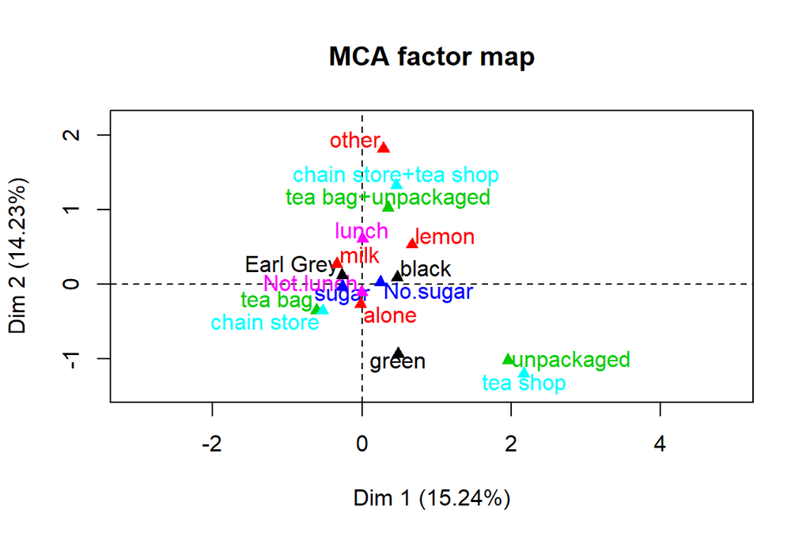

```r
plot(mca, invisible=c("ind"), habillage = "quali")
```

I ran MCA with six different variables, which here refer to questions around tea-drinking habits, including preferable tea label, whether or not tea is drank during lunch etc. Turns out, that capturing the variability between the respondents in two dimensions based on the selected six questions is rather hard: the first two dimensions retain circa 30% of the overall variance, which is not that much, implying that the dimensions are not too distinguishable. Indeed, after visualizing the analysis with a biplot, it seems that we are able to classify a great mass of ‘regular’ tea-drinkers, preferring Earl Grey and using mostly tea bags, from the hedonists who get their unpackaged tea from a specialized shop. However, even this categorization requires a bit of imagination.